# Intro to Machine Learning (Assignment 4)

2023-02-14

## PART 1: Implementing a Simple Prediction Pipeline

*** IMPORTANT: SEED WAS SET GLOBALLY PRIOR TO BEGINNING THIS ASSIGNMENT AS CODE WAS RUN CHRONILOGICALLY *** PACKAGES WERE LOADED BEFORE BEGINNING ANALYSIS FOR THIS ASSIGNMENT  
Using the dataset class4_p1.csv, we will fit and evaluate two prediction models using linear regression. The aim of the models are to predict the number of days in a month an individual reported having good physical health (feature name: healthydays).

Let’s first read in our dataset and perform some data cleaning and manipulations.

```r
df_part1 <-
  read_csv("data/class4_p1.csv", col_names = TRUE) %>%
    janitor::clean_names() %>%
# Let's check to see summary statistics and quick glimpse of our data.
   glimpse()
```

```
## ──────────────────────────────────────────────────────── Delimiter: "," dbl
## (17): ...1, chronic1, chronic3, chronic4, bmi, tobacco1, alcohol1, gpaq8...
```

```
## Rows: 3,811
## Columns: 17
## $ x1           <dbl> 1, 2, 3, 4, 5, 6, 7, 8, 9, 10, 11, 12, 13, 14, 15, 16, 17…
## $ chronic1     <dbl> 2, 2, 1, 2, 2, 1, 1, 1, 1, 2, 2, 2, 1, 1, 1, 1, 1, 2, 1, …
## $ chronic3     <dbl> 2, 2, 1, 2, 2, 1, 1, 1, 1, 2, 2, 2, NA, 2, 2, 1, 2, 2, 2,…
## $ chronic4     <dbl> 2, 2, 2, 1, 2, 2, 2, 2, 2, 2, 2, 2, 1, 2, 2, 2, 2, 2, 2, …
## $ bmi          <dbl> 26.77441, 28.18891, 39.15126, 42.50945, 22.31201, 28.4780…
## $ tobacco1     <dbl> 3, 3, 1, 3, 3, 3, 3, 3, 3, 2, 1, 3, 2, 3, 3, 3, 3, 3, 2, …
## $ alcohol1     <dbl> 3, 3, 2, 3, NA, 2, 2, 3, 2, 2, 3, 3, 3, 3, NA, 3, 3, 2, 3…
## $ gpaq8totmin  <dbl> 0, 120, 60, 180, 0, 0, 0, 0, 15, 0, 60, 0, 0, 120, 60, 0,…
## $ gpaq11days   <dbl> 5, 5, 3, 5, 7, 7, 7, 5, 5, 7, 3, 6, 7, 5, 7, 7, 7, 5, 7, …
## $ habits5      <dbl> 3, 1, 1, 2, 2, 3, 2, 3, 4, 2, 1, 2, 3, 2, 1, 2, 2, 3, 2, …
## $ habits7      <dbl> NA, NA, NA, NA, NA, NA, NA, NA, NA, NA, NA, NA, NA, NA, N…
## $ agegroup     <dbl> 1, 3, 3, 2, 2, 3, 3, 4, 3, 2, 2, 2, 3, 3, 3, 3, 3, 2, 2, …
## $ dem3         <dbl> 2, 2, 1, 2, 2, 1, 1, 1, 2, 1, 2, 2, 2, 2, 2, 2, 2, 2, 2, …
## $ dem4         <dbl> 1, 2, 1, 1, 2, 2, 1, 1, 1, 1, 2, 2, 2, 2, 2, 2, 1, 1, 1, …
## $ dem8         <dbl> 2, 2, 1, 2, 2, 1, 2, 2, 1, 1, 1, 1, 2, 1, 2, 2, 2, 1, 1, …
## $ povertygroup <dbl> 1, 3, 6, 2, 6, 3, 4, 6, 3, 1, 2, 1, 1, 4, 3, 1, 1, 1, 6, …
## $ healthydays  <dbl> 24, 30, NA, 23, 30, 30, 30, 10, 0, 30, 0, 30, NA, 29, 30,…
```

From the output above, we notice that all our features are stored as ‘dbl’, continuous variables. Therefore, we will use the output above in addition to the codebook to store our features in the intended format. In addition we will also remove all missing values. We remove the variable “x1” that has the count of the number of observations in the dataset.

```r
df_part1 <-
  df_part1 %>%
    # Delete 'x1' that shows number of observations in dataset (serves no purpose for us)
  select(-x1) %>%
  ## Converting categorical variables to factor variables
  mutate(
     chronic1 = as.factor(chronic1),
     chronic3 = as.factor(chronic3),
     chronic4 = as.factor(chronic4),
     tobacco1 = as.factor(tobacco1),
     alcohol1 = as.factor(alcohol1),
     habits5 = as.factor(habits5),
     habits7 = as.factor(habits7),
     agegroup = as.factor(agegroup),
     dem3 = as.factor(dem3),
     dem4 = as.factor(dem4),
     dem8 = as.factor(dem8),
     povertygroup = as.factor(povertygroup)
  ) %>%
  # Remove all missing values
  na.omit()


  # Let's quickly look at our dataset and the new feature types
  summary(df_part1)
```

```
##  chronic1 chronic3 chronic4      bmi        tobacco1 alcohol1  gpaq8totmin
##  1: 655   1: 250   1: 140   Min.   : 9.09   1: 237   1:  67   Min.   :  0.00
##  2:1540   2:1945   2:2055   1st Qu.:23.23   2: 118   2: 661   1st Qu.:  0.00
##                             Median :26.57   3:1840   3:1467   Median :  0.00
##                             Mean   :27.42                     Mean   : 44.91
##                             3rd Qu.:30.19                     3rd Qu.: 60.00
##                             Max.   :99.83                     Max.   :900.00
##    gpaq11days    habits5  habits7 agegroup dem3     dem4     dem8
##  Min.   :0.000   1: 661   1:283   1:167    1: 904   1: 476   1:1399
##  1st Qu.:2.000   2:1049   2:613   2:665    2:1291   2:1719   2: 796
##  Median :5.000   3: 380   3:793   3:851
##  Mean   :4.241   4: 105   4:403   4:512
##  3rd Qu.:7.000            5:103
##  Max.   :7.000
##  povertygroup  healthydays
##  1:413        Min.   : 0.00
##  2:365        1st Qu.:27.00
##  3:371        Median :30.00
##  4:357        Mean   :26.42
##  5:506        3rd Qu.:30.00
##  6:183        Max.   :30.00
```

Our categorical (factor) variables are:  
chronic1, chronic3, chronic4, tobacco1, alcohol1, habits5, habits7, agegroup, dem3, dem4, dem8 and povertygroup.

Our continuous variables are:  
bmi, gpaq8totmin, gpaq11days and healthydays.

### Scaling and Centering

Before, we partition our dataset, we will scale and center all the numeric features in our data.

```r
scaled_part1 <-
  df_part1 %>%
    select(bmi,gpaq8totmin, gpaq11days) %>%
      scale(center=TRUE, scale = TRUE)

## Bind scaled variables to original dataset
df_part1_final <-
  df_part1 %>%
       select(-bmi,-gpaq8totmin, -gpaq11days) %>%
           cbind(scaled_part1)
```

### Next, let’s partition our dataset into training and testing using the caret package.

```r
  #Create balanced partitons and ensure balance of outcome (healthydays
partition_df <-createDataPartition(df_part1_final$healthydays, p=0.7, list=FALSE)

  #Let's create our training set from this partition
df_train <- df_part1_final[partition_df,]

  #Let's create our testing set from this partition
df_test <- df_part1_final[-partition_df,]

  #Let's view number of rows in each set
NROW(df_train)
```

```
## [1] 1537
```

```r
NROW(df_test)
```

```
## [1] 658
```

The results above show that our training dataset contains 1,537 rows, which accounts for roughly 70% of the original dataset. Also, we can see that our testing dataset contains 658 rows, which roughly account for 30% of the original dataset. We can be confident that we correctly partitioned our original dataset in the manner we would like, a 70/30 split.

1. Now let’s fit two prediction models using different subsets of the features in the training data.The aim of the models are to predict the number of days in a month an individual reported having good physical health (feature name: healthydays)

```r
#Model 1
lin_model_fit1 <-
  df_train %>%
     lm(healthydays ~ dem3 + bmi + gpaq8totmin + gpaq11days, data = .)

print(lin_model_fit1)
```

```
##
## Call:
## lm(formula = healthydays ~ dem3 + bmi + gpaq8totmin + gpaq11days,
##     data = .)
##
## Coefficients:
## (Intercept)        dem32          bmi  gpaq8totmin   gpaq11days
##    26.76351     -0.54674     -0.47571      0.03531      0.73357
```

```r
#Model 2
lin_model_fit2 <-
  df_train %>%
     lm(healthydays ~ dem3 + agegroup + bmi + chronic1 +  gpaq11days +
          chronic3 + chronic4 + povertygroup, data = .)

print(lin_model_fit2)
```

```
##
## Call:
## lm(formula = healthydays ~ dem3 + agegroup + bmi + chronic1 +
##     gpaq11days + chronic3 + chronic4 + povertygroup, data = .)
##
## Coefficients:
##   (Intercept)          dem32      agegroup2      agegroup3      agegroup4
##      19.35157       -0.04306       -1.07929       -2.39010       -2.41525
##           bmi      chronic12     gpaq11days      chronic32      chronic42
##       0.05558        2.03064        0.61195        1.69366        4.30336
## povertygroup2  povertygroup3  povertygroup4  povertygroup5  povertygroup6
##       0.87670        3.34202        2.93921        2.89667        1.29111
```

```r
# Utilize root mean square error here to evaluate our model
rmse(lin_model_fit1, df_test)
```

```
## [1] 7.743694
```

```r
rmse(lin_model_fit2, df_test)
```

```
## [1] 7.479584
```

From the application of the root mean square error in our regression models, we can see that model 2 has the lowest mean square error indicating that this model is better at predicting ‘healthydays’ compared to model2 .

3. One setting where the implementation of the model selected here would be useful is in clinical healthcare for a population of older adults. An app could be used to collect the features listed in model 2 from medical records with informed consent and use that information to help make recommendations about how users/patients can improve or have healthier days in a month.

## PART 2: Conducting an Unsupervised Analysis

Using the built-in R dataset USArrests we identified clusters using hierarchical analysis. In addtiion,, we used an ‘agglomerative’ algorithm for hierarchical clustering and a ‘Euclidian’ distance measure to construct our dissimilarity matrix.

```r
## Read in USArrests dataset and save as df_part2
  data("USArrests")

## Let's see roughly what this dataset looks like and check to see if any missing values exist
  glimpse(USArrests)
```

```
## Rows: 50
## Columns: 4
## $ Murder   <dbl> 13.2, 10.0, 8.1, 8.8, 9.0, 7.9, 3.3, 5.9, 15.4, 17.4, 5.3, 2.…
## $ Assault  <int> 236, 263, 294, 190, 276, 204, 110, 238, 335, 211, 46, 120, 24…
## $ UrbanPop <int> 58, 48, 80, 50, 91, 78, 77, 72, 80, 60, 83, 54, 83, 65, 57, 6…
## $ Rape     <dbl> 21.2, 44.5, 31.0, 19.5, 40.6, 38.7, 11.1, 15.8, 31.9, 25.8, 2…
```

From the ‘glimpse’ function, we see that all our features are of a continuous data type.

```r
## Let's check to see if there are any missing values for our features
which(is.na(USArrests))
```

```
## integer(0)
```

It appears that there aren’t any missing values in our dataset. Therefore, we can produce on with our analysis.

```r
## Let's check the means and standard deviations of our features
colMeans(USArrests)
```

```
##   Murder  Assault UrbanPop     Rape
##    7.788  170.760   65.540   21.232
```

```r
apply(USArrests, 2, sd, na.rm=TRUE)
```

```
##    Murder   Assault  UrbanPop      Rape
##  4.355510 83.337661 14.474763  9.366385
```

By checking the means and standard deviations of our features, we notice that their values are not similar. Therefore, we need to center and scale our features before performing clustering so that we have a standard deviation of 1 and a mean of zero.

```r
## Let's perform scaling and centering here
USArrests_2 <-
 USArrests %>%
    scale(center=TRUE, scale = TRUE)

## Let's check the new mean and std after the scaling process
colMeans(USArrests_2)
```

```
##        Murder       Assault      UrbanPop          Rape
##  1.543210e-16  1.115774e-16 -4.307665e-16  8.704149e-16
```

```r
apply(USArrests_2, 2, sd, na.rm=TRUE)
```

```
##   Murder  Assault UrbanPop     Rape
##        1        1        1        1
```

4. We now see that our means are similar in addition to our standard deviation. We will now proceed to perform our hierarchical clustering.  
   First, we have to decide how to handle cluster dissimilarity. We use a “euclidean” method to calculate the distance and performed hierarchical clustering using “complete linkage”.

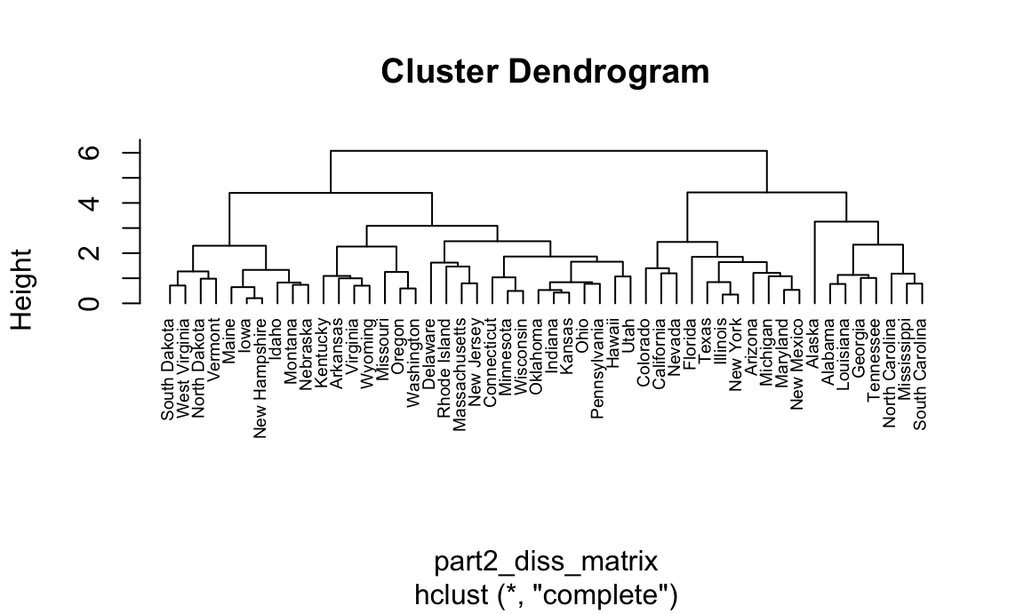

```r
## Let's create a dissimilarity matrix
part2_diss_matrix <-
  dist(USArrests_2, method = "euclidean")

# Let's perform agglomerative Hierarchical clustering using Complete Linkage
clusters_fit <-
  hclust(part2_diss_matrix, method = "complete" )

# Let's plot the obtained dendrogram
plot(clusters_fit, cex = 0.6, hang = -1)
```

From the dendrogram above, we can see the clusters of the features in our dataset by each state in the US.  
Now, we must determine the optimal number of clusters by using the gap statistic.

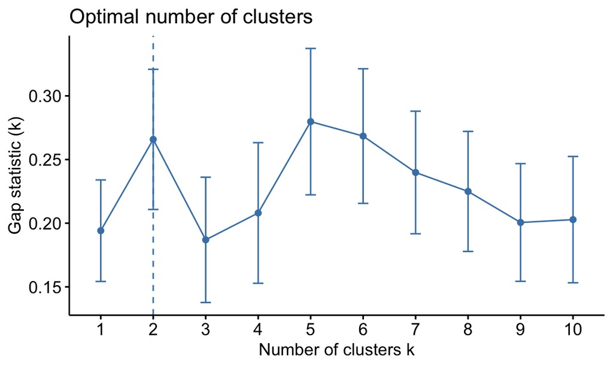

```r
set.seed(1)

#create function to use within clusGap
hclusCut <- function(x, k) list(cluster = cutree(hclust(dist(x, method="euclidian"), method="average"), k=k))

gap_stat <-clusGap(USArrests_2, FUN = hclusCut, K.max = 10, B = 50)

## Let's plot the gap statistic
fviz_gap_stat(gap_stat)
```

1. From the gap statistic plot above, we can see that the optimal number of clusters is 2. Now, we’ll use the number of clusters from the gap statistic to obtain cluster assignment for each observation in the dataset.

```r
set.seed(1)

clusters_h3<-cutree(clusters_fit, k=2)

table(clusters_h3)
```

```
## clusters_h3
##  1  2
## 19 31
```

```r
input.feature.vals<-cbind(USArrests_2,cluster=clusters_h3) %>% as_tibble()

input.feature.vals %>%
  group_by(cluster) %>%
  summarise_all(mean)
```

```
## # A tibble: 2 × 5
##   cluster Murder Assault UrbanPop   Rape
##     <dbl>  <dbl>   <dbl>    <dbl>  <dbl>
## 1       1  1.04    1.06     0.192  0.852
## 2       2 -0.639  -0.651   -0.118 -0.522
```

2. In the states included in cluster 1, all of the features in our data (murder, assualt, rape and urban population) are above the mean. States in cluster 2 have far lower means for the features in our data (murder, assault, rape and urban population).
5. One research question that can be addressed using the newly identified clusters, is “How does demographic population, meaning diversity of population, predict the cost of living among states in the United States?”

Scientific and ethical considerations to consider before using these clusters include:  
- collecting data that is representative of the population to eliminate algorithmic bias  
- utilizing theory from the literature and experts to determine features that are needed to be inputted into the algorithm